# **D213 Time Series Analysis**

## Nicole Reiswig

College of Information Technology, Western Governors University

Master of Science in Data Analytics

Dr. Festus Elleh

March 14, 2024

### Part I: Research Question

1. One research question we will answer with this analysis is, “Are there recurring patterns for seasonal effects in revenue?”
2. The goal of this time series analysis is to utilize the provided data set which includes date and revenue data to study revenue trends over time and understand seasonal fluctuations. This data can be utilized to predict future outcomes.

### Part II: Method Justification

1. An assumption of time series analysis is stationarity. Stationarity refers to when a change in time does not affect a change in the shape of the distribution. Another assumption of time series analysis is autocorrelation. Autocorrelation quantifies how related one data point is to another.

### Part III: Data Preparation

##### To prepare the data the first action was to install pmdarima through the anaconda powershell prompt. Then the proper packages were imported to the analysis.

```python
# pip install pmdarima
```

```python
#import packages needed
import pandas as pd
import numpy as np
import matplotlib.pyplot as plt
%matplotlib inline
import seaborn as sns
from dateutil.parser import parse
import warnings
warnings.filterwarnings('ignore')
import os
from datetime import datetime
from statsmodels.tsa.seasonal import seasonal_decompose
import statsmodels.api
```

##### Then, we examine the working directory, import the data, set the index, and remove null values.

```python
#check working directory
directory_path = os.getcwd()
print("My current directory is : "+ directory_path)
```

```
My current directory is : C:\Users\ntrei
```

```python
#importing the data, set index
df=pd.read_csv('Telecomtimeseriesdataset.csv', index_col='Day', parse_dates=True)
```

```python
#getting rid of null values
df=df.dropna()
```

```python
#view shape of data
print('Shape of data:', df.shape)
df.head()
```

```
Shape of data: (731, 1)
```

| Day | Revenue |
| --- | --- |
| 1 | 0.000000 |
| 2 | 0.000793 |
| 3 | 0.825542 |
| 4 | 0.320332 |
| 5 | 1.082554 |

```python
df.tail()
```

| Day | Revenue |
| --- | --- |
| 727 | 16.931559 |
| 728 | 17.490666 |
| 729 | 16.803638 |
| 730 | 16.194813 |
| 731 | 16.620798 |

```python
df.info()
```

```
<class 'pandas.core.frame.DataFrame'>
Index: 731 entries, 1 to 731
Data columns (total 1 columns):
 #   Column   Non-Null Count  Dtype
---  ------   --------------  -----
 0   Revenue  731 non-null    float64
dtypes: float64(1)
memory usage: 11.4 KB
```

Next, we viewed and explored the data.

```python
df.describe()
```

|  | Revenue |
| --- | --- |
| count | 731.000000 |
| mean | 9.822901 |
| std | 3.852645 |
| min | 0.000000 |
| 25% | 6.872836 |
| 50% | 10.785571 |
| 75% | 12.566911 |
| max | 18.154769 |

```python
df['Date'] = (pd.date_range(start=datetime(2022, 1, 1),
                           periods=df.shape[0], freq='24H'))

df.set_index('Date' ,inplace=True)
df
```

| Date | Revenue |
| --- | --- |
| 2022-01-01 | 0.000000 |
| 2022-01-02 | 0.000793 |
| 2022-01-03 | 0.825542 |
| 2022-01-04 | 0.320332 |
| 2022-01-05 | 1.082554 |
| ... | ... |
| 2023-12-28 | 16.931559 |
| 2023-12-29 | 17.490666 |
| 2023-12-30 | 16.803638 |
| 2023-12-31 | 16.194813 |
| 2024-01-01 | 16.620798 |

731 rows × 1 columns

##### The "Day" variable was changed to "Date" and transformed from 1,2,3,etc. to yyyy-mm-dd format to prepare for the time series analysis.

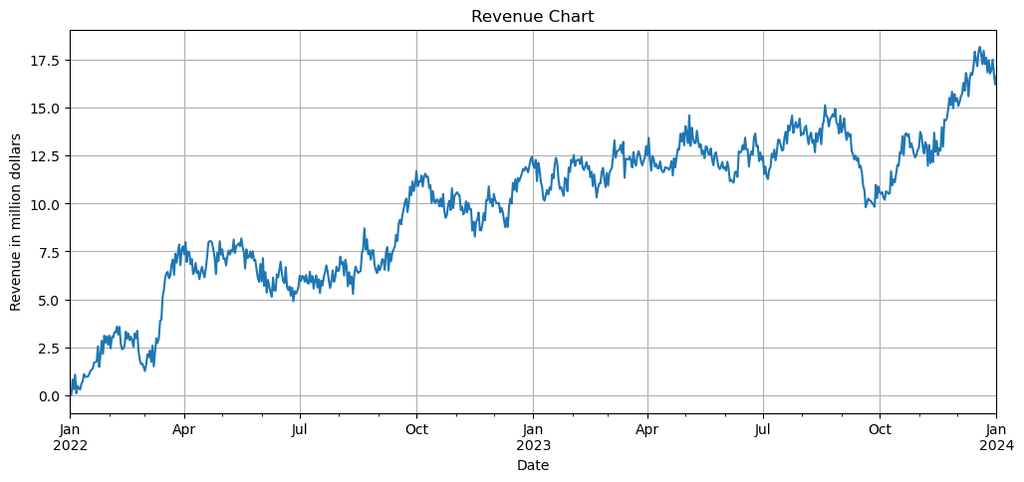

```python
#plotting time series
df['Revenue'].plot(figsize=(12,5))
plt.title('Revenue Chart')
plt.xlabel('Date')
plt.ylabel('Revenue in million dollars')
plt.grid(True)
plt.show()
```

```python
#looking for nulls
df.isnull().any()
```

```
Revenue    False
dtype: bool
```

```python
#drop any null columns
df = df.dropna()
```

```python
df.isnull().values.any()
```

```
False
```

```python
#check for missing values
df.isna().sum()
```

```
Revenue    0
dtype: int64
```

##### After viewing the data in the line graph above, we verified again there are no nulls or missing values. Lastly, we export the cleaned data set.

```python
#export cleaned data set
pd.DataFrame(df).to_csv("cleaned_telecom213.csv")
```

### Part IV: Model Identification and Analysis

##### The annotated findings with visualizations of the data analysis include the following components:

```python
#testing stationarity
from statsmodels.tsa.stattools import adfuller
def ad_test(dataset):
    dftest = adfuller(dataset, autolag = 'AIC')
    print("1. ADF: ", dftest[0])
    print("2. P-value: ", dftest[1])
    print("3. Num of Lags:", dftest[2])
    print("4. Num of Obs Used for ADF Regression and Critical Values Calc:", dftest[3])
    print("5. Critical Values: ")
    for key, val in dftest[4].items():
        print("\t",key,": ",val)

ad_test(df['Revenue'])
```

```
1. ADF:  -1.924612157310183
2. P-value:  0.3205728150793967
3. Num of Lags: 1
4. Num of Obs Used for ADF Regression and Critical Values Calc: 729
5. Critical Values:
	 1% :  -3.4393520240470554
	 5% :  -2.8655128165959236
	 10% :  -2.5688855736949163
```

##### The data is not stationary, therefore we will run diff() to make it stationary so that the mean and variance constant.

```python
#make the time series stationary
df_stationary = df.diff().dropna()
df_stationary.head(5)
```

| Date | Revenue |
| --- | --- |
| 2022-01-02 | 0.000793 |
| 2022-01-03 | 0.824749 |
| 2022-01-04 | -0.505210 |
| 2022-01-05 | 0.762222 |
| 2022-01-06 | -0.974900 |

```python
#test for stationarity again
result = adfuller(df_stationary['Revenue'])
print("Test statistics: ", result[0])
print("p-value: ", result[1])
print("critical values: ", result[4])

if result[1]<= 0.05:
    print("Reject null hypothesis, the time series is stationary")
else:
    print("Fail to reject null hypothesis, the time series is non-stationary")
```

```
Test statistics:  -44.87452719387599
p-value:  0.0
critical values:  {'1%': -3.4393520240470554, '5%': -2.8655128165959236, '10%': -2.5688855736949163}
Reject null hypothesis, the time series is stationary
```

##### After running diff() we now see that the data is stationary because the p-value is 0.0 which is below the critical value of .05.

```python
from pmdarima import auto_arima
stepwise_fit=auto_arima(df_stationary['Revenue'],trace=True, suppress_warnings=True)
stepwise_fit.summary()
```

```
Performing stepwise search to minimize aic
 ARIMA(2,0,2)(0,0,0)[0] intercept   : AIC=987.305, Time=0.96 sec
 ARIMA(0,0,0)(0,0,0)[0] intercept   : AIC=1162.819, Time=0.10 sec
 ARIMA(1,0,0)(0,0,0)[0] intercept   : AIC=983.122, Time=0.14 sec
 ARIMA(0,0,1)(0,0,0)[0] intercept   : AIC=1019.369, Time=0.16 sec
 ARIMA(0,0,0)(0,0,0)[0]             : AIC=1162.139, Time=0.08 sec
 ARIMA(2,0,0)(0,0,0)[0] intercept   : AIC=985.104, Time=0.17 sec
 ARIMA(1,0,1)(0,0,0)[0] intercept   : AIC=985.106, Time=0.11 sec
 ARIMA(2,0,1)(0,0,0)[0] intercept   : AIC=986.045, Time=0.79 sec
 ARIMA(1,0,0)(0,0,0)[0]             : AIC=984.710, Time=0.07 sec

Best model:  ARIMA(1,0,0)(0,0,0)[0] intercept
Total fit time: 2.607 seconds
```

SARIMAX Results

| Dep. Variable: | y | No. Observations: | 730 |
| --- | --- | --- | --- |
| Model: | SARIMAX(1, 0, 0) | Log Likelihood | -488.561 |
| Date: | Wed, 20 Mar 2024 | AIC | 983.122 |
| Time: | 09:57:57 | BIC | 996.901 |
| Sample: | 01-02-2022 | HQIC | 988.438 |
|  | - 01-01-2024 |  |  |
| Covariance Type: | opg |  |  |

|  | coef | std err | z | P>\|z\| | [0.025 | 0.975] |
| --- | --- | --- | --- | --- | --- | --- |
| intercept | 0.0332 | 0.018 | 1.895 | 0.058 | -0.001 | 0.068 |
| ar.L1 | -0.4692 | 0.033 | -14.296 | 0.000 | -0.534 | -0.405 |
| sigma2 | 0.2232 | 0.013 | 17.801 | 0.000 | 0.199 | 0.248 |

| Ljung-Box (L1) (Q): | 0.00 | Jarque-Bera (JB): | 2.05 |
| --- | --- | --- | --- |
| Prob(Q): | 0.96 | Prob(JB): | 0.36 |
| Heteroskedasticity (H): | 1.02 | Skew: | -0.02 |
| Prob(H) (two-sided): | 0.85 | Kurtosis: | 2.74 |

Warnings:  
[1] Covariance matrix calculated using the outer product of gradients (complex-step).

##### Auto ARIMA tells us it believes the best model will be 1,0,0 with no seasonality 0,0,0, and no periodicity 0.

```python
# checking for duplicates
df_stationary.duplicated().any()
```

```
False
```

```python
from statsmodels.tsa.arima.model import ARIMA
print(df_stationary.shape)
train = df_stationary.iloc[:-30]
test = df_stationary.iloc[-30:]
print(train.shape, test.shape)
```

```
(730, 1)
(700, 1) (30, 1)
```

```python
model = ARIMA(train['Revenue'],order=(1,0,0))
model = model.fit()
model.summary()
```

SARIMAX Results

| Dep. Variable: | Revenue | No. Observations: | 700 |
| --- | --- | --- | --- |
| Model: | ARIMA(1, 0, 0) | Log Likelihood | -465.219 |
| Date: | Wed, 20 Mar 2024 | AIC | 936.439 |
| Time: | 09:58:04 | BIC | 950.092 |
| Sample: | 01-02-2022 | HQIC | 941.716 |
|  | - 12-02-2023 |  |  |
| Covariance Type: | opg |  |  |

|  | coef | std err | z | P>\|z\| | [0.025 | 0.975] |
| --- | --- | --- | --- | --- | --- | --- |
| const | 0.0217 | 0.012 | 1.802 | 0.072 | -0.002 | 0.045 |
| ar.L1 | -0.4737 | 0.033 | -14.216 | 0.000 | -0.539 | -0.408 |
| sigma2 | 0.2211 | 0.013 | 17.625 | 0.000 | 0.197 | 0.246 |

| Ljung-Box (L1) (Q): | 0.07 | Jarque-Bera (JB): | 1.43 |
| --- | --- | --- | --- |
| Prob(Q): | 0.80 | Prob(JB): | 0.49 |
| Heteroskedasticity (H): | 0.97 | Skew: | -0.00 |
| Prob(H) (two-sided): | 0.81 | Kurtosis: | 2.78 |

Warnings:  
[1] Covariance matrix calculated using the outer product of gradients (complex-step).

##### Here we test PDQ 1,0,0 based on auto ARIMA finding this to be the best fit model when running through AIC. Auto ARIMA states there is no seasonality as the second set of numbers after PDQ is 0,0,0 and there is no periodicity.

```python
model = ARIMA(train['Revenue'],order=(1,1,0))
model = model.fit()
model.summary()
```

SARIMAX Results

| Dep. Variable: | Revenue | No. Observations: | 700 |
| --- | --- | --- | --- |
| Model: | ARIMA(1, 1, 0) | Log Likelihood | -651.162 |
| Date: | Wed, 20 Mar 2024 | AIC | 1306.324 |
| Time: | 09:58:05 | BIC | 1315.423 |
| Sample: | 01-02-2022 | HQIC | 1309.841 |
|  | - 12-02-2023 |  |  |
| Covariance Type: | opg |  |  |

|  | coef | std err | z | P>\|z\| | [0.025 | 0.975] |
| --- | --- | --- | --- | --- | --- | --- |
| ar.L1 | -0.7428 | 0.026 | -28.633 | 0.000 | -0.794 | -0.692 |
| sigma2 | 0.3768 | 0.021 | 18.286 | 0.000 | 0.336 | 0.417 |

| Ljung-Box (L1) (Q): | 74.67 | Jarque-Bera (JB): | 0.61 |
| --- | --- | --- | --- |
| Prob(Q): | 0.00 | Prob(JB): | 0.74 |
| Heteroskedasticity (H): | 1.00 | Skew: | -0.06 |
| Prob(H) (two-sided): | 0.99 | Kurtosis: | 2.91 |

Warnings:  
[1] Covariance matrix calculated using the outer product of gradients (complex-step).

```python
model = ARIMA(train['Revenue'],order=(1,0,5))
model = model.fit()
model.summary()
```

SARIMAX Results

| Dep. Variable: | Revenue | No. Observations: | 700 |
| --- | --- | --- | --- |
| Model: | ARIMA(1, 0, 5) | Log Likelihood | -464.049 |
| Date: | Wed, 20 Mar 2024 | AIC | 944.099 |
| Time: | 09:58:07 | BIC | 980.507 |
| Sample: | 01-02-2022 | HQIC | 958.173 |
|  | - 12-02-2023 |  |  |
| Covariance Type: | opg |  |  |

|  | coef | std err | z | P>\|z\| | [0.025 | 0.975] |
| --- | --- | --- | --- | --- | --- | --- |
| const | 0.0218 | 0.013 | 1.656 | 0.098 | -0.004 | 0.048 |
| ar.L1 | -0.9156 | 0.242 | -3.776 | 0.000 | -1.391 | -0.440 |
| ma.L1 | 0.4513 | 0.247 | 1.828 | 0.068 | -0.033 | 0.935 |
| ma.L2 | -0.1672 | 0.118 | -1.415 | 0.157 | -0.399 | 0.064 |
| ma.L3 | 0.1453 | 0.079 | 1.833 | 0.067 | -0.010 | 0.301 |
| ma.L4 | -0.0445 | 0.054 | -0.827 | 0.408 | -0.150 | 0.061 |
| ma.L5 | 0.0136 | 0.045 | 0.301 | 0.763 | -0.075 | 0.102 |
| sigma2 | 0.2204 | 0.013 | 17.433 | 0.000 | 0.196 | 0.245 |

| Ljung-Box (L1) (Q): | 0.00 | Jarque-Bera (JB): | 1.73 |
| --- | --- | --- | --- |
| Prob(Q): | 0.99 | Prob(JB): | 0.42 |
| Heteroskedasticity (H): | 0.97 | Skew: | -0.03 |
| Prob(H) (two-sided): | 0.81 | Kurtosis: | 2.76 |

Warnings:  
[1] Covariance matrix calculated using the outer product of gradients (complex-step).

##### Here we test PDQ 1,0,5 based on this being the example given in my course work. The best AIC score is on model 1,0,0 as auto ARIMA stated.

[output not shown]

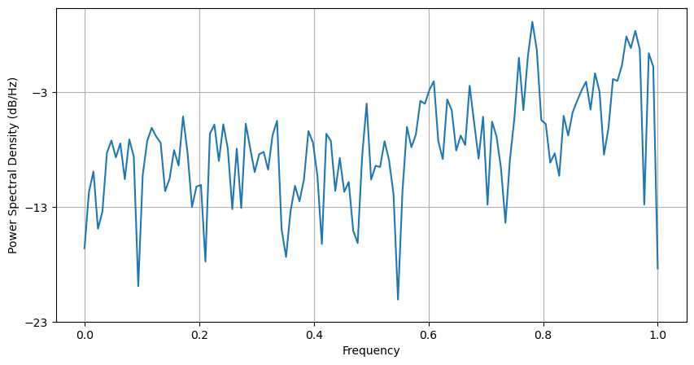

```python
#spectral analysis
plt.figure(figsize=(10,5), linewidth=3)
plt.psd(df_stationary['Revenue'])
```

##### There is no observable pattern or seasonality in the spectral density graph, which tells us that ARIMA is the right model to run.

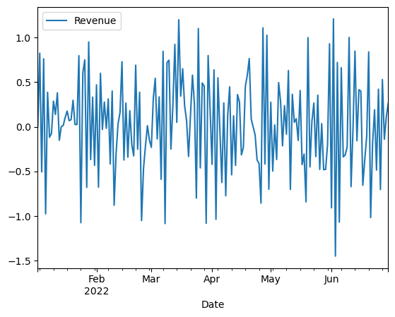

```python
#check for seasonality
df_stationary.loc[:'2022-06-30'].plot()
```

##### There is no observable seasonality. The mean line is at zero which is where we want it.

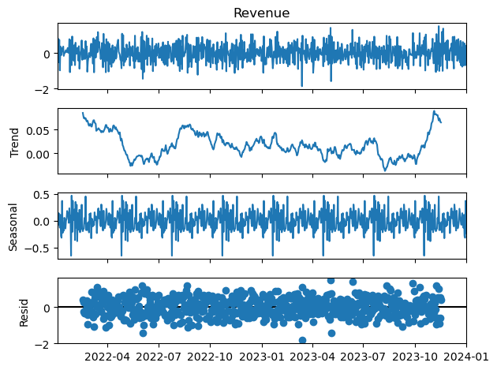

```python
#perform decomposition
decomp = seasonal_decompose(df_stationary['Revenue'], period=90)

#plot decomposition
decomp.plot()
plt.show()
```

##### The first graph is the revenue data. The second graph is the trend line after decomposition.

##### The third graph is the seasonal graph after decomposition. The fourth graph is residuals after decomposition with the center line on zero.

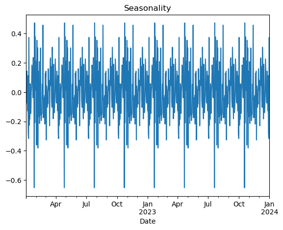

```python
#plot seasonality
plt.title('Seasonality')
decomp.seasonal.plot()
```

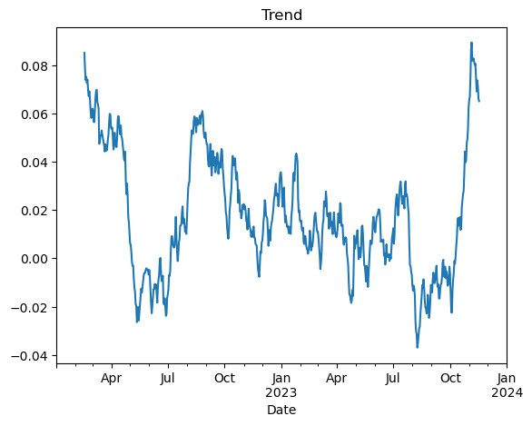

```python
plt.title('Trend')
decomp.trend.plot()
```

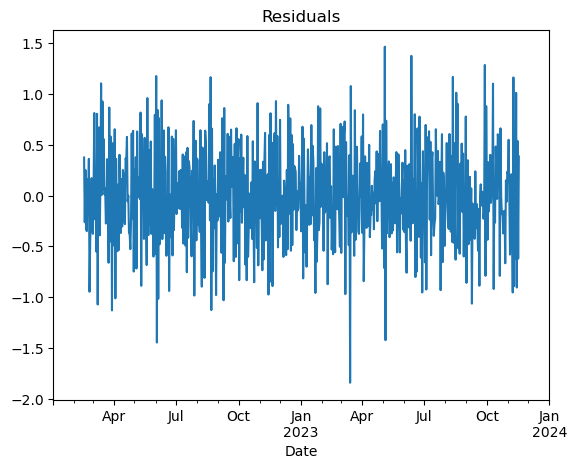

```python
plt.title('Residuals')
decomp.resid.plot()
```

##### The center line of the mean value of the residuals is 0 which is what we want.

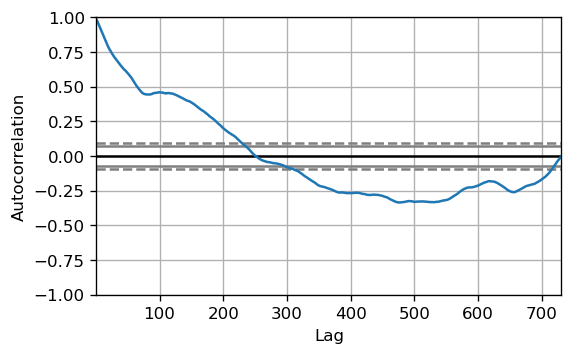

```python
#autocorrelation on original datat set
plt.rcParams.update({'figure.figsize':(5,3), 'figure.dpi':120})
pd.plotting.autocorrelation_plot(df.Revenue.tolist())
```

##### Autocorrelation before data was stationary

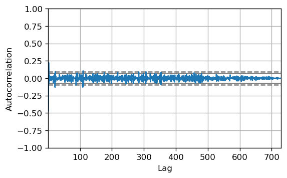

```python
#autocorrelation on differenced data set
plt.rcParams.update({'figure.figsize':(5,3), 'figure.dpi':120})
pd.plotting.autocorrelation_plot(df_stationary.Revenue.tolist())
```

##### Autocorrelation after data is stationary

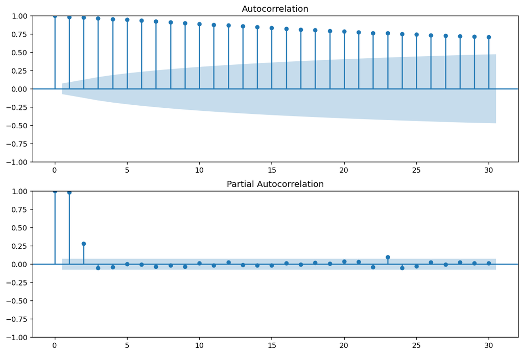

```python
#graphing acf plot on original data set
import statsmodels.api as sm
fig = plt.figure(figsize=(12,8))
ax1 = fig.add_subplot(211)
fig = sm.graphics.tsa.plot_acf(df.Revenue, lags=30, ax=ax1)

#graphing the pacf plot on original data set
ax2 = fig.add_subplot(212)
fig = sm.graphics.tsa.plot_pacf(df.Revenue, lags=30, ax=ax2)
plt.show()
```

##### Here is our ACF and PACF graph before differencing. There is a gradual decline in the lags which demonstrates that the data is not yet stationary.

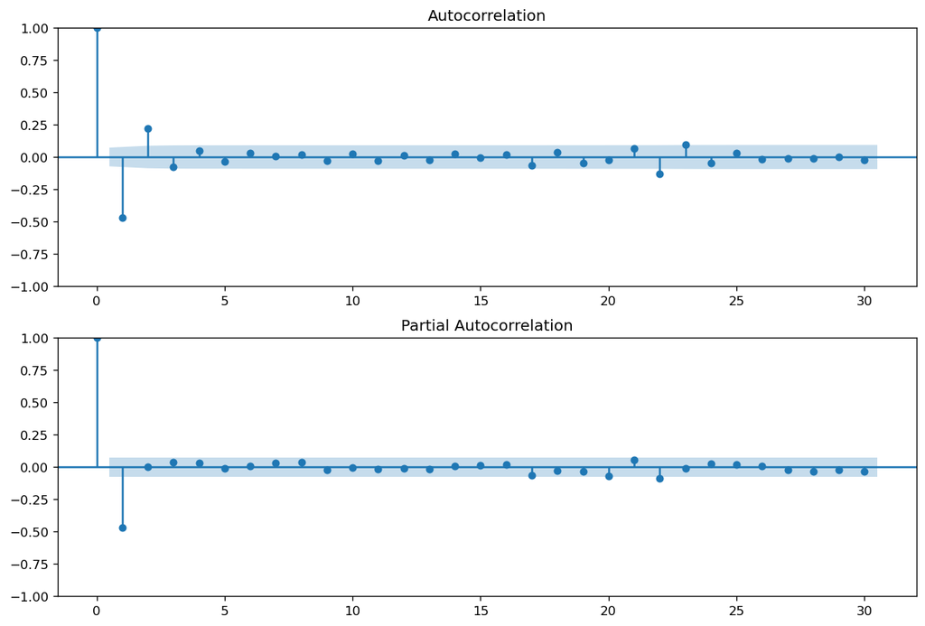

```python
#graphing acf plot on differenced data set
import statsmodels.api as sm
fig = plt.figure(figsize=(12,8))
ax1 = fig.add_subplot(211)
fig = sm.graphics.tsa.plot_acf(df_stationary.Revenue, lags=30, ax=ax1)

#graphing the pacf plot on differenced
ax2 = fig.add_subplot(212)
fig = sm.graphics.tsa.plot_pacf(df_stationary.Revenue, lags=30, ax=ax2)
plt.show()
```

##### Here is our ACF and PACF graph after differencing. Autocorrelation is the q value of the acf graph. Partial autocorrelation is the p value of the pacf graph. Most of the values are statistically insignificant because they are under the blue area.

```python
#split stationary to train and test
df_train = df_stationary.iloc[:364]
df_train
```

| Date | Revenue |
| --- | --- |
| 2022-01-02 | 0.000793 |
| 2022-01-03 | 0.824749 |
| 2022-01-04 | -0.505210 |
| 2022-01-05 | 0.762222 |
| 2022-01-06 | -0.974900 |
| ... | ... |
| 2022-12-27 | -0.107863 |
| 2022-12-28 | -0.169725 |
| 2022-12-29 | 0.348312 |
| 2022-12-30 | 0.319666 |
| 2022-12-31 | 0.150207 |

364 rows × 1 columns

```python
df_test = df_stationary.iloc[365:]
df_test
```

| Date | Revenue |
| --- | --- |
| 2023-01-02 | -0.141204 |
| 2023-01-03 | 0.415539 |
| 2023-01-04 | -1.108194 |
| 2023-01-05 | 0.961947 |
| 2023-01-06 | -0.351247 |
| ... | ... |
| 2023-12-28 | 0.170280 |
| 2023-12-29 | 0.559108 |
| 2023-12-30 | -0.687028 |
| 2023-12-31 | -0.608824 |
| 2024-01-01 | 0.425985 |

365 rows × 1 columns

```python
# export file to csv
df_train.to_csv('df_train213.csv', index = False)
df_test.to_csv('df_test213.csv', index = False)
```

```python
start=len(train)
end=len(train)+len(test)-1
pred=model.predict(start=start, end=end, type='levels')
print(pred)
pred.index=df.index[start:end+1]
```

```
2023-12-03    0.244214
2023-12-04   -0.129233
2023-12-05    0.112729
2023-12-06   -0.047107
2023-12-07    0.080173
2023-12-08   -0.031683
2023-12-09    0.070729
2023-12-10   -0.023037
2023-12-11    0.062812
2023-12-12   -0.015788
2023-12-13    0.056176
2023-12-14   -0.009712
2023-12-15    0.050613
2023-12-16   -0.004619
2023-12-17    0.045950
2023-12-18   -0.000350
2023-12-19    0.042041
2023-12-20    0.003229
2023-12-21    0.038764
2023-12-22    0.006230
2023-12-23    0.036017
2023-12-24    0.008745
2023-12-25    0.033714
2023-12-26    0.010853
2023-12-27    0.031784
2023-12-28    0.012620
2023-12-29    0.030166
2023-12-30    0.014101
2023-12-31    0.028810
2024-01-01    0.015343
Freq: D, Name: predicted_mean, dtype: float64
```

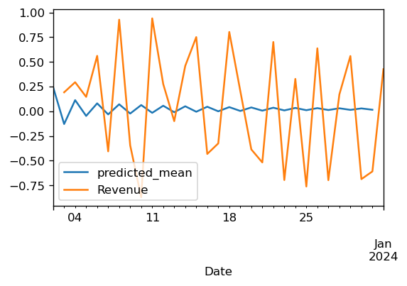

```python
pred.plot(legend=True)
test['Revenue'].plot(legend=True)
```

```python
test['Revenue'].mean()
```

```
0.051428953333333284
```

##### The test mean is .051

```python
from sklearn.metrics import mean_squared_error
from math import sqrt
rmse = sqrt(mean_squared_error(pred,test['Revenue']))
print(rmse)
```

```
0.5684338664539683
```

##### RMSE is .568, this is not a bad score but is not optimal as the closer to 0 the score is the better.

```python
model2=ARIMA(df_stationary['Revenue'],order=(1,0,0))
model2 = model2.fit()
df.tail()
```

| Date | Revenue |
| --- | --- |
| 2023-12-28 | 16.931559 |
| 2023-12-29 | 17.490666 |
| 2023-12-30 | 16.803638 |
| 2023-12-31 | 16.194813 |
| 2024-01-01 | 16.620798 |

```python
index_future_dates = pd.date_range(start='2024-01-01', end='2025-01-01')
print(index_future_dates)
pred=model2.predict(start=len(df_stationary), end=len(df_stationary)+366, typ='levels').rename('ARIMA Predictions')
pred.index=index_future_dates
print(pred)
```

```
DatetimeIndex(['2024-01-01', '2024-01-02', '2024-01-03', '2024-01-04',
               '2024-01-05', '2024-01-06', '2024-01-07', '2024-01-08',
               '2024-01-09', '2024-01-10',
               ...
               '2024-12-23', '2024-12-24', '2024-12-25', '2024-12-26',
               '2024-12-27', '2024-12-28', '2024-12-29', '2024-12-30',
               '2024-12-31', '2025-01-01'],
              dtype='datetime64[ns]', length=367, freq='D')
2024-01-01   -0.166684
2024-01-02    0.111411
2024-01-03   -0.019078
2024-01-04    0.042151
2024-01-05    0.013421
                ...
2024-12-28    0.022596
2024-12-29    0.022596
2024-12-30    0.022596
2024-12-31    0.022596
2025-01-01    0.022596
Freq: D, Name: ARIMA Predictions, Length: 367, dtype: float64
```

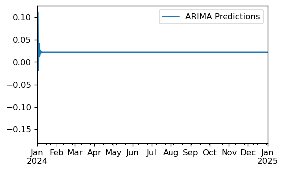

```python
pred.plot(legend=True)
```

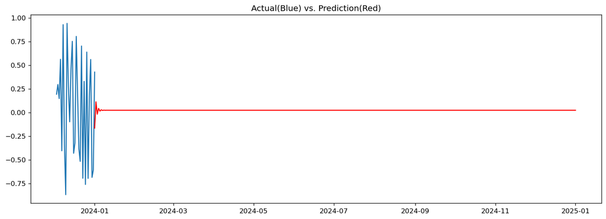

```python
# plot forecasts against actual outcomes
plt.figure(figsize=(15,5))
plt.title('Actual(Blue) vs. Prediction(Red)')
plt.plot(test)
plt.plot(pred, color='red')
plt.show()
```

### Part V: Data Summary and Implications

##### The annotated visualization of the forecast of the final model compared to the test set can be seen above.

##### Based on these findings the recommended course of action is to run additional tests to determine which variables will increase revenue over the next year.

### Part VI: Reporting

##### References for sections of code:

Elleh, Festus. (2024). D213 Data Preprocessing in Python. https://wgu.hosted.panopto.com/Panopto/Pages/Viewer.aspx?id=8d32afc8-d66f-42d5-9117-b100016cf9ac

Dr. Sewell. (2024). ARIMA I. https://wgu.hosted.panopto.com/Panopto/Pages/Viewer.aspx?id=358071e7-9c01-4274-a044-af7400ec1c40

Dr. Sewell. (2024). D213 ARIMA II. https://wgu.hosted.panopto.com/Panopto/Pages/Viewer.aspx?id=37007075-c29e-43f2-a106-af7800d45914